# TP7: temporal models

Author

Lionel Hertzog

Published

August 18, 2026

## 1 Objectives

This practical aims at fitting temporal structure in regression models to study both temporal trends and account for temporal autocorrelation in data.

We will use a dataset of the number of cut trees found on NFI plots per months between 2005 and 2020.

## 2 Read the data

Load the `dat_tp7.csv` into R. Perform quick exploration of the dataset.

```r
here::i_am("practicals/tp7.qmd")
dat <- read.csv("../data/dat_tp7.csv")

## turn year_month into a date format
dat$year_month <- lubridate::ymd(dat$year_month)

head(dat)
```

```
  year_month nb_tree nb_cut
1 2004-11-01    4053    211
2 2004-12-01    3902    239
3 2005-01-01    4464    235
4 2005-02-01    4608    318
5 2005-03-01    5601    258
6 2005-04-01    5800    243
```

Metadata:

- year_month: year and month of the observation
- nb_tree: total number of trees observed by the NFI in the first visit
- nb_cut: number of trees found cut at the second visit after 5 years

## 3 Data exploration

Explore the data, produce graphs of the changes in **nb_tree**, **nb_cut** and **nb_cut / nb_tree** over time. Do you see patterns emerging?

## 4 Trend analysis

Trend analysis consists in estimating the changes in the response variables (here the number of cut trees) over time.

### 4.1

Fit a first model with a simple linear trend to the data, take into account the fact that the number of trees change over time. Plot the resulting trend together with the data. What do you think of this model?

**TipHint**

An option is to fit a binomial model with

```r
glm(p_cut ~ time, ...)
```

With **p_cut** the proportion of cut trees and time a numeric index of **year_month**

**TipSolution**

```r
dat$time <- as.numeric(dat$year_month)
dat$p_cut <- with(dat, nb_cut / nb_tree)
(m <- glm(p_cut ~ time, data = dat, weights = nb_tree, family = "binomial"))
```

```
Call:  glm(formula = p_cut ~ time, family = "binomial", data = dat,
    weights = nb_tree)

Coefficients:
(Intercept)         time
  -3.870675     0.000073

Degrees of Freedom: 190 Total (i.e. Null);  189 Residual
Null Deviance:      5202
Residual Deviance: 4314     AIC: 5762
```

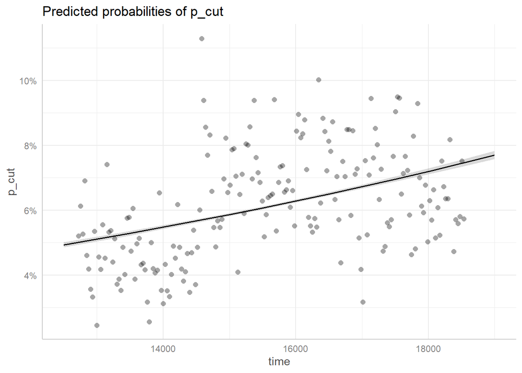

```r
pp <- ggeffects::predict_response(m, terms = "time")
plot(pp, show_data = TRUE)
```

### 4.2

More flexible trends can be fitted using polynomials, fit a trend model with a polynomial of degree 3 to the data. Compare the fit to the simple linear trend, which model would you prefer?

**TipHint**

Polynomial can be added to the model via

```r
glm(p_cut ~ time + I(time^2) + ..., ...)
```

## 5 Breakpoint analysis

A temporal trend can have abrupt breakpoints with changing slope at specific time points. To perform a breakpoint analysis in R, one can use the *segmented* package with the `segmented` function.

Run a segmented analysis on the fitted linear trend model (with no polynomials). Does the function identify breakpoints? Plot the resulting trend using the `predict` function. Which model do you prefer between the three that we saw so far?

**TipSolution**

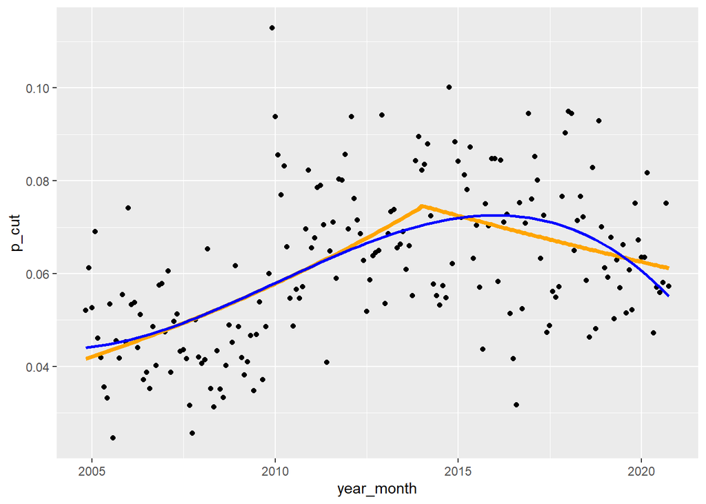

```r
library(segmented)
library(tidyverse)

ss <- segmented(m)
dat$pred_seg <- predict(ss, type = "response")

ggplot(dat, aes(x = year_month)) +
  geom_point(aes(y=p_cut)) +
  geom_line(aes(y = pred_seg), color = "orange", linewidth = 1.5) +
  stat_smooth(aes(y = p_cut),method = "lm",
              formula = y ~ poly(x, 3),
              se = FALSE, color = "blue")
```

## 6 Autocorrelation

Autocorrelation is the process by which observations are not independent to each other. This can violate the assumption of independence of the observation made by regression models to accurately estimate the uncertainty around the regression parameters (and so the confidence intervals, the p-values …).

### 6.1

The first step is to identify if autocorrelation is an issue. This require fitting a model with no time component and evaluate if the residuals show correlation depending on the temporal structure.

Fit a simple linear model to the data:

```
glm(p_cut ~ 1, ...)
```

DHARMa can check for temporal autocorrelation in the residuals via the `testTemporalAutocorrelation` function. Test if there is temporal autocorrelation in the residual of the fitted model.

**TipSolution**

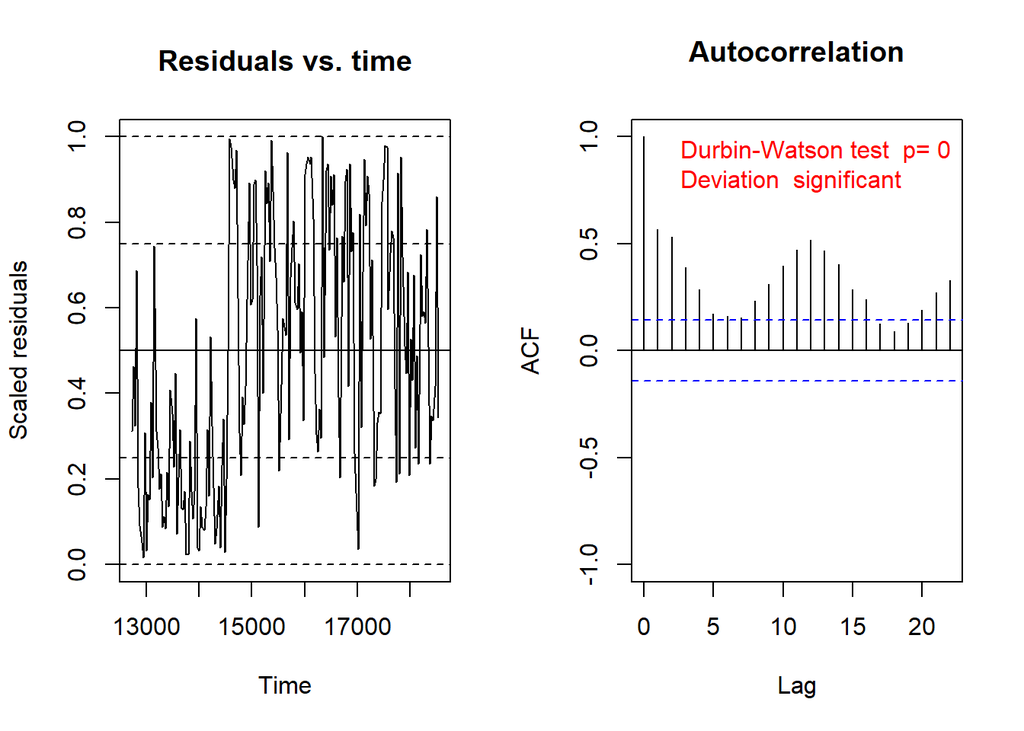

```
    Durbin-Watson test

data:  simulationOutput$scaledResiduals ~ 1
DW = 0.86343, p-value = 2.899e-15
alternative hypothesis: true autocorrelation is not 0
```

```r
library(DHARMa)
m <- glm(p_cut ~ 1, data = dat, weights = nb_tree)
rr <- simulateResiduals(m)
testTemporalAutocorrelation(rr, time = dat$time)
```

### 6.2

An easy way to account for autocorrelation is through hierarchical model with varying intercept per time point.

Fit such a model and plot the prediction. Is this model able to capture the temporal variation in the data?

### 6.3

Hierarchical models do not account however for the temporal proximity of the data, the fact that two point close in time should be more correlated than two point further apart.

Explicit autocorrelation structure can be added to regression model with the *glmmTMB* package via such formula call:

```
glmmTMB(y ~ 1 + ar1(time_f + 0 | grp))
```

With *time_f* a factor of the time points and *grp* a grouping variable that allow potential group-specific AR-effect. For this practical all observation belong to the same group.

Fit such a model to our data and explore the model output, what represent the different parameters?

**TipSolution**

```r
library(glmmTMB)

dat$time_f <- factor(dat$time)
dat$grp <- 1

m_tmb <- glmmTMB(p_cut ~ 1 + ar1(time_f + 0 | grp),
             data = dat, weights = nb_tree,
             family = "binomial")
summary(m_tmb)
```

```
 Family: binomial  ( logit )
Formula:          p_cut ~ 1 + ar1(time_f + 0 | grp)
Data: dat
Weights: nb_tree

      AIC       BIC    logLik -2*log(L)  df.resid
   2199.0    2208.7   -1096.5    2193.0       188

Random effects:

Conditional model:
 Groups Name        Variance Std.Dev. Corr
 grp    time_f12723 0.08802  0.2967   0.62 (ar1)
Number of obs: 191, groups:  grp, 1

Conditional model:
            Estimate Std. Error z value Pr(>|z|)
(Intercept)   -2.766      0.044  -62.85   <2e-16 ***
---
Signif. codes:  0 '***' 0.001 '**' 0.01 '*' 0.05 '.' 0.1 ' ' 1
```

### 6.4

Plot the resulting predicted time serie and compare it to the hierarchical model. Do you see differences? What are the benefits of using the AR1 structure? What issues do you see with these model fit?

**TipSolution**

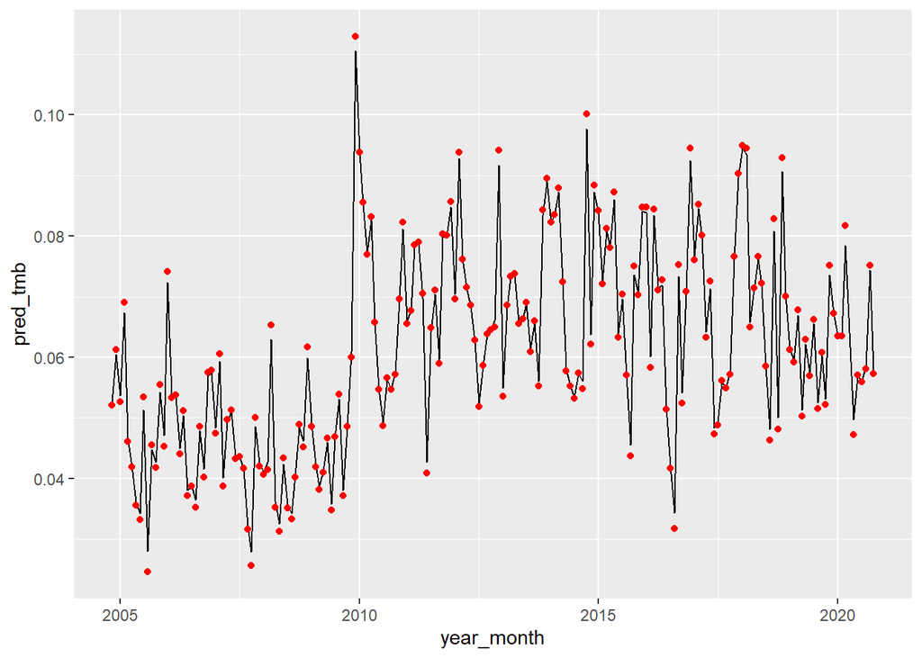

```r
dat$pred_tmb <- predict(m_tmb, type = "response")

ggplot(dat, aes(x = year_month, y = pred_tmb)) +
  geom_line() +
  geom_point(aes(y = p_cut), color = "red")
```

### 6.5 Bonus

Make a model that combine a trend analysis (with polynomials if needed) with a structure that take into account the autocorrelation (either through hierarchical or AR1 term).

Write 1-2 sentences about the estimated parameters and the trend in tree cuttings.